#### **Relatório - Aula de ajuste de distribuição**

```r
# Carregando os dados
sinistro <- read.csv("sinistro_automoveis.csv", sep = ",")
sinistro <- sinistro$x
```

#### **Estatística Descritiva**

**A função da estatística descritiva é descrever e resumir um conjunto de dados, com vários recursos como histograma, média, mediana, variância, valores máximos e mínimos e quartis.**

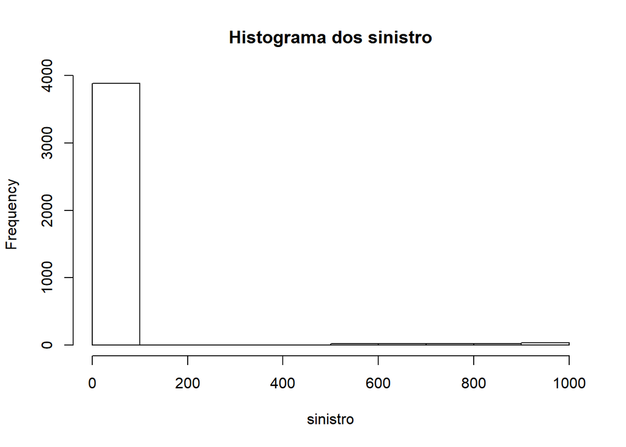

```r
# Histrograma
hist(sinistro, main = "Histograma dos sinistro")
```

```r
# Estatísticas Descritivas
summary(sinistro)
```

```
##    Min. 1st Qu.  Median    Mean 3rd Qu.    Max.
##   1.000   3.916   6.367  35.132  11.059 999.000
```

```r
media <- mean(sinistro)
desvio <- sd(sinistro)
n <- length(sinistro)
```

**E o que foi dito visualizando o histograma pode ser percebido analisando o Summary dos dados. O terceiro quartil representa 75% dos dados ordenados e têm um valor de 11.059 muito abaixo da média 35.132 dos sinistros, então posso dizer que 75% dos sinistros estão abaixo da média. O valor mínimo é de 1 e o máximo é 999.**

```r
# Função para calcular diversas estatísticas
estatisticas <- function(x){
  x <- x[!is.na(x)] # isso serve para que ele omita as observações com NA
  me <- mean(x)
  med <- median(x)
  n <- length(x)
  s <- sd(x)
  mi <- min(x)
  ma <- max(x)
  q25 <- quantile(x, probs = 0.25)
  q75 <- quantile(x, probs = 0.75)
  return(c(n = n, media = me, mediana = med, desvio = s,
           Q = q25, Q = q75, min = mi, max = ma))
}
```

**Uma função que deixa automático um conjunto de comandos sobre estatística descritiva**

```r
# calculando as estatísticas descritivas
estatisticas(sinistro)
```

```
##          n      media    mediana     desvio      Q.25%      Q.75%
## 4010.00000   35.13158    6.36650  137.98676    3.91625   11.05925
##        min        max
##    1.00000  999.00000
```

**Encontrando as estatísticas descritivas por meio da função criada anteriormente**

#### **Gráfico de densidade e de distribuição acumulada**

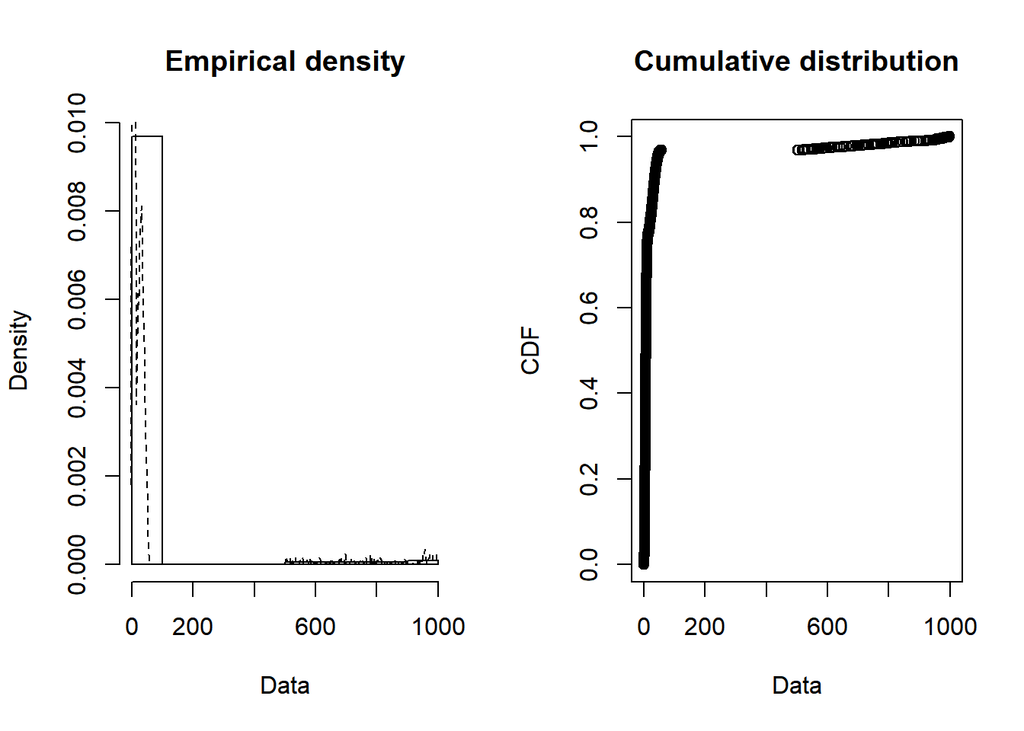

```r
# Função do pacote que cria dois gráficos, o histograma e a acumulada
plotdist(sinistro, histo=TRUE, demp = TRUE)
```

**Como temos disponível apenas uma amostra e não conhecemos a distribuição que gerou os dados, os gráficos tem a função deixar mais intuitivo a visualização da possível distribuição.**

**Gráficos de densidade são utilizados para se conhecer a forma da distribuição dos dados e mostra a probabilidade de um intervalo do gráfico, nele é possível ver que os dados estão próximos de 0 e o outros de 500 até 999.**

#### **Gráfico de Cullen e Frey**

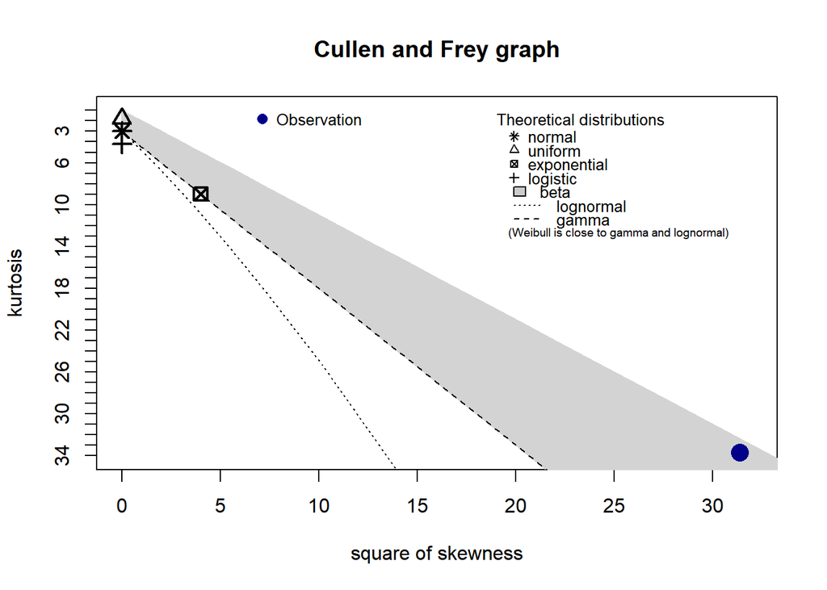

```
## summary statistics
## ------
## min:  1   max:  999
## median:  6.3665
## mean:  35.13158
## estimated sd:  137.9868
## estimated skewness:  5.601705
## estimated kurtosis:  33.70483
```

```r
# Função que demonstra o gráfico de Cullen e Frey cuja função é apresentar a proximidade da distribuição observada em relação às teóricas, tomando como base a curtose e assimetria
descdist(sinistro)
```

**A partir do Gráfico de Cullen and Frey, é possível achar a distribuição que melhor explique os sinistros, Como o ponto de observação (azul) está dentro de beta, essa é a distribuição que provavelmente melhor explica os dados.**

**Curtose é característica de forma um achatamento e skewness é a característica de assimetria**

#### **Estimação de parâmetros por máxima-verossimilhança**

**A função fitdist retorna os parâmetros das distribuições escolhidas**

```r
# Realizando as estimações
fitg <- fitdist(sinistro, "gamma")
fitg
```

```
## Fitting of the distribution ' gamma ' by maximum likelihood
## Parameters:
##         estimate   Std. Error
## shape 0.43605240 0.0079187255
## rate  0.01240804 0.0003695573
```

**Para Gama o parâmetro de forma(shape) é 0.4361 com um grau de dispersão de 0.0079 um valor bem pequeno isso indica que o parâmetro está bem próximo do valor real, e o parâmetro de taxa(rate) é de 0.0124 com uma dispersão do valor real de 0.0003.**

```r
# Estimando os parâmetros para uma Weibull
fitw <- fitdist(sinistro, "weibull")
fitw
```

```
## Fitting of the distribution ' weibull ' by maximum likelihood
## Parameters:
##         estimate  Std. Error
## shape  0.5886422 0.005828678
## scale 15.8894196 0.454579510
```

**Para Weibull o parâmetro de forma(shape) é 0.5886 com um grau de dispersão de 0.0058 um valor bem pequeno isso indica que o parâmetro está bem próximo do valor real, e o parâmetro de escala(scale) é de 15.8894 com uma dispersão do valor real de 0.4546.**

```r
# Estimando os parâmetros para uma Lognormal
fitln <- fitdist(sinistro, "lnorm")
fitln
```

```
## Fitting of the distribution ' lnorm ' by maximum likelihood
## Parameters:
##         estimate Std. Error
## meanlog 2.070761 0.01939672
## sdlog   1.228289 0.01371551
```

**Para Lognomal o parâmetro de log-média(meanlog) é 2.0708 com um grau de dispersão de 0.01934 um valor bem pequeno isso indica que o parâmetro está bem próximo do valor real, e o parâmetro log-desvio(sdlog) é de 1.2282 com uma dispersão do valor real de 0.0137**

#### **Comparando graficamente as distribuições teóricas e estimadas**

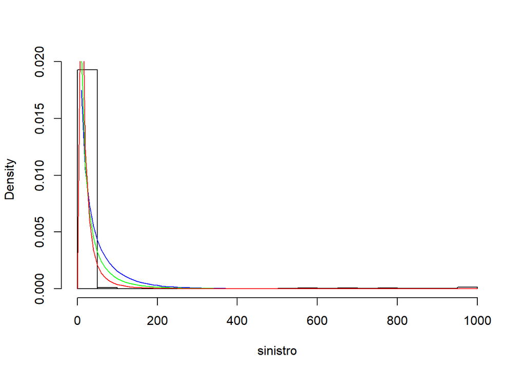

```r
# Visualizando a distribuição empírica em relação às estimadas
hist(sinistro, pch=20, breaks = 20, prob = TRUE, main = "")
curve(dgamma(x, shape = fitg$estimate[1], rate = fitg$estimate[2]), add = TRUE, col = "blue")
curve(dweibull(x, fitw$estimate[1], fitw$estimate[2]), add = TRUE, col = "green")
curve(dlnorm(x, fitln$estimate[1], fitln$estimate[2]), add = TRUE, col = "red")
```

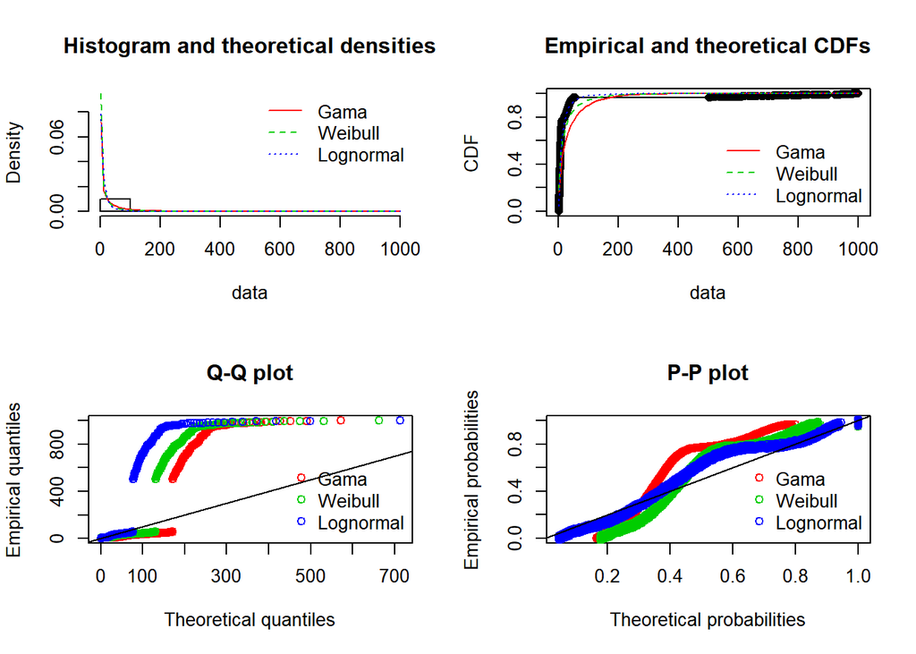

```r
# Criar quatro gráficos: Densidade, Acumulada, QQ-plot e PP-plot
par(mfrow=c(2,2))
plot.legend <- c("Gama","Weibull", "Lognormal")
denscomp(list(fitg,fitw, fitln), legendtext = plot.legend)
cdfcomp (list(fitg,fitw, fitln), legendtext = plot.legend)
qqcomp  (list(fitg,fitw,fitln), legendtext = plot.legend)
ppcomp  (list(fitg,fitw,fitln), legendtext = plot.legend)
```

**denscomp plota o histograma contra funções de densidade ajustada;**

**cdfcomp é capaz de traçar ajustes de uma distribuição discreta;**

**qqcomp plota quantis teóricos contra empíricos;**

**ppcomp plota probabilidades teóricas contra empíricas.**

#### **Testes**

```r
# Para finalizar a análise, avaliaremos o Teste Kolmogorov-Sminorv e o critério informacional de Akaike com a função gofstat
gofstat(list(fitg,fitw, fitln), fitnames = c("Gama","Weibull", "LogNormal"))
```

```
## Goodness-of-fit statistics
##                                     Gama     Weibull   LogNormal
## Kolmogorov-Smirnov statistic   0.2957612   0.1972282   0.1535529
## Cramer-von Mises statistic   115.0247663  60.8853078  21.2916973
## Anderson-Darling statistic   595.4945997 357.2617449 119.6375528
##
## Goodness-of-fit criteria
##                                    Gama  Weibull LogNormal
## Akaike's Information Criterion 33900.96 32162.69  29640.48
## Bayesian Information Criterion 33913.55 32175.28  29653.07
```

**O teste Kolmogorov-Sminorv observa a diferença absoluta entre a distribuição escolhida no caso Gama, Weibull e Lognormal e a função empírica que os dados seguem, compara-se esse valor com um p-valor, dado um nível de significância, Para dizer se a função é adequada ou não, é necessário fazer o teste de hipótese ks.test e descobrir o p-valor e chegar a conclusão se rejeita ou não a hipótese nula.**

**A AIC Akaike estima a quantidade informações perdidas por um modelo: quanto menos informações um modelo perde, maior a qualidade desse modelo.**